# Godoberi Dictonary analysis

G. Moroz

## Приведет словарь к нужному виду

```r
library(tidyverse)
theme_set(theme_bw())
godoberi <- read_csv("../godoberi_dict_v2.csv")
godoberi
```

```
## # A tibble: 5,719 x 6
##       id lemma    morphology    bor definition              source
##    <dbl> <chr>    <chr>       <dbl> <chr>                   <chr>
##  1     1 АБÁДАЛIИ <NA>           NA нареч. 1) никогда; аба… "<p lang=\"ru-И́U\"…
##  2     2 АБÁДИЛ-… <NA>           NA то же, что абáдалIи     "<p lang=\"ru-И́U\"…
##  3     3 АБАЗИ́Н…  (-щуб)          1 I (-щуб) абазинец       "<p lang=\"ru-И́U\"…
##  4     4 АБАЗИ́Н…  (-лълъилIи)     1 II (-лълъилIи) абазинка "<p lang=\"ru-И́U\"…
##  5     5 АБАЗИ́Н…  (-рдуб)         1 (-рдуб) абазины; абази… "<p lang=\"ru-И́U\"…
##  6     6 АБТÁБУС… (-улIи, -а…     1 III (-улIи, -абе) авто… "<p lang=\"ru-И́U\"…
##  7     7 АБТАРУ́…  (-лIи, -бé)     1 III (-лIи, -бé) автору… "<p lang=\"ru-И́U\"…
##  8     8 АБТÉКА   (-лIи, -бé)     1 III (-лIи, -бé) аптека… "<p lang=\"ru-И́U\"…
##  9     9 АБХÁЗА/В (-щуб)          1 I (-щуб) абхазец        "<p lang=\"ru-И́U\"…
## 10    10 АБХÁЗА/Й (-лълъилIи)     1 II (-лълъилIи) абхазка  "<p lang=\"ru-И́U\"…
## # … with 5,709 more rows
```

Некоторые слова в словаре имеют два варианта, например `БАЖÁРИ // БАЖЕ̄́Р`. Эти случаи следует разнести на разные строчки. Отсортируем заимствования (размечены вручную), суффиксы, звукоподражания, многословные входы, слова из селения Зибирхали и косвенные формы.

```r
godoberi %>%
  separate(lemma, into = c("lemma1", "lemma"), sep = " // ", fill = "right") %>%
  pivot_longer(names_to = 'lem_n', values_to = "lemma", lemma1:lemma) %>%
  select(-lem_n) %>%
  filter(is.na(bor), # заимствования
         !str_detect(lemma, "^-"), # суффиксы
         !str_detect(lemma, "\\s"), # многословные входы
         !str_detect(lemma, "\\S//\\S"), # многословные входы
         !str_detect(definition, "^\\(?зиб.\\)? см."), # Зибирхали
         !str_detect(definition, "звукоподр"), # Звукоподражания
         !str_detect(definition, "возглас, которым"), # Звукоподражания
         !str_detect(definition, "отгонный возглас"), # Звукоподражания
         !str_detect(definition, "подзывной клич"), # Звукоподражания
         !str_detect(definition, "^.{4} п. от ") # косвенные формы
         ) %>%
  mutate(lemma = str_to_upper(lemma),
         lemma = str_remove_all(lemma, "-"),
         lemma = str_remove_all(lemma, "/"),
         lemma = str_remove(lemma, "\\("),
         lemma = str_remove(lemma, "\\)"),
         lemma = str_remove(lemma, "\\!$"), # конечный восклицательный знак
         lemma = str_remove(lemma, "\\?$") # конечный выпросительный знак
         ) ->
  godoberi
```

Получилось 4837 слов, уникальных слов 4733. Проанализируем какие символы встречаются в нашем словаре:

```r
library(tidytext)
godoberi %>%
  unnest_tokens(output = "letter", lemma, token = "characters", to_lower = FALSE) %>%
  count(letter) %>%
  pull(letter)
```

```
##  [1] "Á" "Ā" "É" "Ē" "ᴴ" "I" "Ó" "Ō" "А" "А̄́" "Б" "В" "Г" "Д" "Е" "Е̄́" "Ж" "З" "И"
## [20] "И́" "Ӣ" "Ӣ́" "Й" "К" "Л" "М" "Н" "О" "О̄́" "П" "Р" "С" "Т" "У" "У́" "Ӯ" "Ӯ́" "Х"
## [39] "Ц" "Ч" "Ш" "Щ" "Ъ" "Ь" "Э" "Э́" "Э̄́" "Я" "Я́" "Я̄́"
```

Каждого гласного должно быть максимум по 4 (безударный, ударный, долгий, долгий ударный). То, что `А`, `Е` и `О` отсортировались отдельно означает, что перед нами латинские буквы. Напишем правила преобразования в IPA:

```r
godoberi %>%
  mutate(lemma2 = str_replace_all(lemma, "́", "S"),
         lemma2 = str_replace_all(lemma2, "̄", "D"),
         lemma2 = str_replace_all(lemma2, "Á", "АS"),
         lemma2 = str_replace_all(lemma2, "Ā", "АD"),
         lemma2 = str_replace_all(lemma2, "É", "ЕS"),
         lemma2 = str_replace_all(lemma2, "Ē", "ЕD"),
         lemma2 = str_replace_all(lemma2, "Ó", "ОS"),
         lemma2 = str_replace_all(lemma2, "Ō", "ОD"),
         lemma2 = str_replace_all(lemma2, "DSᴴ", "ᴴDS"),
         lemma2 = str_replace_all(lemma2, "Dᴴ", "ᴴD"),
         lemma2 = str_replace_all(lemma2, "Sᴴ", "ᴴS"),
         IPA = str_replace_all(lemma2, "ЛЪЛЪ", "-ɬː-"),
         IPA = str_replace_all(IPA, "ЦIЦIВ", "-tsːʷ-"),
         IPA = str_replace_all(IPA, "ЦIЦI", "-tsː-"),
         IPA = str_replace_all(IPA, "ХIХI", "-ħː-"),
         IPA = str_replace_all(IPA, "(?<=(Г|К|КК|КI|ХЬ))Еᴴ", "-ʲ-ẽ-"),
         IPA = str_replace_all(IPA, "(?<=(Г|К|КК|КI|ХЬ))Иᴴ", "-ʲ-ĩ-"),
         IPA = str_replace_all(IPA, "(?<=(Г|К|КК|КI|ХЬ))Яᴴ", "-ʲ-ã-"),
         IPA = str_replace_all(IPA, "(?<=(Г|К|КК|КI|ХЬ))Е", "-ʲ-e-"),
         IPA = str_replace_all(IPA, "(?<=(Г|К|КК|КI|ХЬ))И", "-ʲ-i-"),
         IPA = str_replace_all(IPA, "(?<=(Г|К|КК|КI|ХЬ))Я", "-ʲ-a-"),
         IPA = str_replace_all(IPA, "А", "-a-"),
         IPA = str_replace_all(IPA, "Е", "-e-"),
         IPA = str_replace_all(IPA, "И", "-i-"),
         IPA = str_replace_all(IPA, "О", "-o-"),
         IPA = str_replace_all(IPA, "У", "-u-"),
         IPA = str_replace_all(IPA, "Э", "-e-"),
         IPA = str_replace_all(IPA, "-D", "D-"),
         IPA = str_replace_all(IPA, "-S", "S-"),
         IPA = str_replace_all(IPA, "-D-S", "DS-"),
         IPA = str_replace_all(IPA, "-ᴴ", "ᴴ"),
         IPA = str_replace_all(IPA, "aᴴ", "ã"),
         IPA = str_replace_all(IPA, "eᴴ", "ẽ"),
         IPA = str_replace_all(IPA, "iᴴ", "ĩ"),
         IPA = str_replace_all(IPA, "oᴴ", "õ"),
         IPA = str_replace_all(IPA, "uᴴ", "ũ"),
         IPA = str_replace_all(IPA, "eᴴ", "ẽ"),
         IPA = str_replace_all(IPA, "D", "ː"),
         IPA = str_replace_all(IPA, "S", "*"), # ударение обозначаю звездочкой
         IPA = str_replace_all(IPA, "ККВ", "kːʷ"),
         IPA = str_replace_all(IPA, "ГЪВ", "-ʁʷ-"),
         IPA = str_replace_all(IPA, "ГЪ", "-ʁ-"),
         IPA = str_replace_all(IPA, "ГЬ", "-h-"),
         IPA = str_replace_all(IPA, "ГI", "-ʕ-"),
         IPA = str_replace_all(IPA, "ГВ", "-ɡʷ-"),
         IPA = str_replace_all(IPA, "ДЖ", "-dʒ-"),
         IPA = str_replace_all(IPA, "КК", "kː"),
         IPA = str_replace_all(IPA, "КВ", "kʷ"),
         IPA = str_replace_all(IPA, "КЪВ", "-q'ʷ-"),
         IPA = str_replace_all(IPA, "КЪ", "-q'-"),
         IPA = str_replace_all(IPA, "КЬВ", "-tɬ'ʷ-"),
         IPA = str_replace_all(IPA, "КЬ", "-tɬ'-"),
         IPA = str_replace_all(IPA, "КIВ", "-k'ʷ-"),
         IPA = str_replace_all(IPA, "КI", "-k'-"),
         IPA = str_replace_all(IPA, "ЛЪ", "-ɬ-"),
         IPA = str_replace_all(IPA, "ЛIВ", "-tɬʷ-"),
         IPA = str_replace_all(IPA, "ЛI", "-tɬ-"),
         IPA = str_replace_all(IPA, "ПI", "-p'-"),
         IPA = str_replace_all(IPA, "СС", "-sː-"),
         IPA = str_replace_all(IPA, "ТТ", "-tː-"),
         IPA = str_replace_all(IPA, "ТIВ", "-t'ʷ-"),
         IPA = str_replace_all(IPA, "ТI", "-t'-"),
         IPA = str_replace_all(IPA, "ХХВ", "-χːʷ-"),
         IPA = str_replace_all(IPA, "ХХ", "-χː-"),
         IPA = str_replace_all(IPA, "ХЪВ", "-qχʷ-"),
         IPA = str_replace_all(IPA, "ХВ", "-χʷ-"),
         IPA = str_replace_all(IPA, "ХЪ", "-qχ-"),
         IPA = str_replace_all(IPA, "ХЬВ", "-xʷ-"),
         IPA = str_replace_all(IPA, "ХЬ", "-x-"),
         IPA = str_replace_all(IPA, "ХIВ", "-ħʷ-"),
         IPA = str_replace_all(IPA, "ХI", "-ħ-"),
         IPA = str_replace_all(IPA, "ЦЦ", "-tsː-"),
         IPA = str_replace_all(IPA, "ЦI", "-ts'-"),
         IPA = str_replace_all(IPA, "ЧЧВ", "-tʃːʷ-"),
         IPA = str_replace_all(IPA, "ЧIВ", "-tʃ'ʷ-"),
         IPA = str_replace_all(IPA, "ЧВ", "-tʃʷ-"),
         IPA = str_replace_all(IPA, "ЧЧ", "-tʃː-"),
         IPA = str_replace_all(IPA, "ЧI", "-tʃ'-"),
         IPA = str_replace_all(IPA, "Б", "-b-"),
         IPA = str_replace_all(IPA, "В", "-w-"),
         IPA = str_replace_all(IPA, "Г", "-ɡ-"),
         IPA = str_replace_all(IPA, "Д", "-d-"),
         IPA = str_replace_all(IPA, "Й", "-j-"),
         IPA = str_replace_all(IPA, "Ж", "-ʒ-"),
         IPA = str_replace_all(IPA, "З", "-z-"),
         IPA = str_replace_all(IPA, "К", "-k-"),
         IPA = str_replace_all(IPA, "Л", "-l-"),
         IPA = str_replace_all(IPA, "М", "-m-"),
         IPA = str_replace_all(IPA, "Н", "-n-"),
         IPA = str_replace_all(IPA, "П", "-p-"),
         IPA = str_replace_all(IPA, "Р", "-r-"),
         IPA = str_replace_all(IPA, "С", "-s-"),
         IPA = str_replace_all(IPA, "Т", "-t-"),
         IPA = str_replace_all(IPA, "Т", "-t-"),
         IPA = str_replace_all(IPA, "Х", "-χ-"),
         IPA = str_replace_all(IPA, "Ц", "-ts-"),
         IPA = str_replace_all(IPA, "Ч", "-tʃ-"),
         IPA = str_replace_all(IPA, "Ш", "-ʃ-"),
         IPA = str_replace_all(IPA, "Щ", "-ʃː-"),
         IPA = str_replace_all(IPA, "Ъ", "-ʔ-"),
         IPA = str_replace_all(IPA, "-{1,}ʲ", "ʲ"),
         IPA = str_replace_all(IPA, "-{2,}", "-"),
         IPA = str_remove(IPA, "^-"),
         IPA = str_remove(IPA, "-$")) %>%
  select(-lemma2) ->
  godoberi_ipa

godoberi_ipa %>%
  select(lemma, IPA, definition)
```

```
## # A tibble: 4,837 x 3
##    lemma      IPA                definition
##    <chr>      <chr>              <chr>
##  1 АБÁДАЛIИ   a-b-a*-d-a-tɬ-i    нареч. 1) никогда; абадалIи йаиччи ден биттиха…
##  2 АБÁДИЛАБÁ… a-b-a*-d-i-l-a-b-… то же, что абáдалIи
##  3 АВАДÁНАБ   a-w-a-d-a*-n-a-b   (-л мн. I, II) весёлый, жизнерадостный; авадан…
##  4 АВÁДАНЛЪА… a-w-a*-d-a-n-ɬ-a-… (и прош., вáдан-лъала, авáданлъалу) понуд. от …
##  5 АВÁДАНЛЪИ  a-w-a*-d-a-n-ɬ-i   III (-лIи) весёлость; жизнерадостность; ракIва…
##  6 АВАДАНЛЪИ́  a-w-a-d-a-n-ɬ-i*   (и повел., авáдан-лъи, аваданлъý) стать весёлы…
##  7 АВÁЛ       a-w-a*-l           III (-áлIи, -бé) квартал; гьаб ищиб авалида эт…
##  8 АВÁЛАХИР   a-w-a*-l-a-χ-i-r   III (-áлIи, тк. ед.) начало и конец; авал-ахир…
##  9 АВАРÁ      a-w-a-r-a*         III (-лIи) 1) препятствие, помеха; гьоб мухулъ…
## 10 АВЛÁХЪИ    a-w-l-a*-qχ-i      III (-илIи, -абé) 1) степь, равнина; гIатIидаб…
## # … with 4,827 more rows
```

Давайте убедимся, что не осталось никаких ошибок. Посмотрим, какие звуки у нас получились:

```r
godoberi_ipa %>%
  unnest_tokens("sound", IPA, token = stringr::str_split, pattern = "-", to_lower = FALSE) %>%
  count(sound) %>%
  pull(sound)
```

```
##  [1] "a"    "ã"    "a*"   "ã*"   "aː"   "ãː"   "aː*"  "ãː*"  "b"    "d"
## [11] "dʒ"   "e"    "e*"   "eː"   "eː*"  "ɡ"    "ɡʲ"   "ɡʷ"   "h"    "ħ"
## [21] "ħː"   "ħʷ"   "i"    "ĩ"    "i*"   "ĩ*"   "iː"   "iː*"  "j"    "k"
## [31] "k'"   "k'ʲ"  "k'ʷ"  "kː"   "kːʲ"  "kːʷ"  "kʲ"   "kʷ"   "l"    "ɬ"
## [41] "ɬː"   "m"    "n"    "o"    "o*"   "oː"   "oː*"  "p"    "p'"   "q'"
## [51] "q'ʷ"  "qχ"   "qχʷ"  "r"    "ʁ"    "ʁʷ"   "s"    "sː"   "ʃ"    "ʃː"
## [61] "t"    "t'"   "t'ʷ"  "tː"   "tɬ"   "tɬ'"  "tɬ'ʷ" "ts"   "ts'"  "tsː"
## [71] "tsːʷ" "tʃ"   "tʃ'"  "tʃ'ʷ" "tʃː"  "tʃʷ"  "u"    "ũ"    "u*"   "ũ*"
## [81] "ũː"   "uː*"  "w"    "x"    "xʲ"   "xʷ"   "z"    "ʒ"    "ʔ"    "ʕ"
## [91] "χ"    "χː"   "χːʷ"  "χʷ"
```

Вот у нас и получилась система звуков. Можно проанализировать их частотность:

```r
library(DT)
godoberi_ipa %>%
  unnest_tokens("sound", IPA, token = stringr::str_split, pattern = "-", to_lower = FALSE) %>%
  count(sound, sort = TRUE) %>%
  datatable()
```

|  | sound | n |
| --- | --- | --- |
| 1 | a | 4447 |
| 2 | i | 3104 |
| 3 | i* | 1752 |
| 4 | r | 1654 |
| 5 | b | 1620 |
| 6 | u | 1565 |
| 7 | a* | 1560 |
| 8 | l | 1453 |
| 9 | n | 1279 |
| 10 | d | 928 |

[output cut: 84 more lines]

Полученное можно разделить на гласные и согласные, посчитать долю, которую и можно записать в стандартный чарт согласных и гласных. Также можно сделать визуализацию, где размером символа показать частотность. Теперь мы готовы перейти к анализу слоговой структуры.

## Анализ слоговой структуры

```r
vowels <- str_c("([auieo]̃?ː?\\*?)")
not_vowels <- str_c("([^auieo]̃?ː?\\*?)")
godoberi_ipa %>%
  mutate(initial = str_extract(IPA, str_c("^.*?", vowels)),
         initial_vowel = str_extract(initial, vowels),
         initial = str_remove(initial, str_c("-?", vowels, ".*")),
         initial = ifelse(initial == "", "#", initial),
         initial_length = ifelse(str_detect(initial, "#"), 0, str_count(initial, "-")+1),
         final = str_extract(IPA, str_c(vowels, not_vowels, "*$")),
         final_vowel = str_extract(final, vowels),
         final = ifelse(str_detect(final, "-"),
                        str_remove(final, str_c(vowels, ".*?-")),
                        "#"),
         final_length = ifelse(str_detect(final, "#"), 0, str_count(final, "-")+1),
         n_syllables = str_count(IPA, "[auieo]")) %>%
  filter(!is.na(final_length)|
           !is.na(initial_length)) ->
  godoberi_ipa_in_fi
godoberi_ipa_in_fi
```

```
## # A tibble: 4,836 x 14
##       id morphology   bor definition source lemma IPA   initial initial_vowel
##    <dbl> <chr>      <dbl> <chr>      <chr>  <chr> <chr> <chr>   <chr>
##  1     1 <NA>          NA нареч. 1)… "<p l… АБÁД… a-b-… #       a
##  2     2 <NA>          NA то же, чт… "<p l… АБÁД… a-b-… #       a
##  3    12 (-л мн. I…    NA (-л мн. I… "<p l… АВАД… a-w-… #       a
##  4    13 (и прош.,…    NA (и прош.,… "<p l… АВÁД… a-w-… #       a
##  5    14 (-лIи)        NA III (-лIи… "<p l… АВÁД… a-w-… #       a
##  6    15 (и повел.…    NA (и повел.… "<p l… АВАД… a-w-… #       a
##  7    16 (-áлIи, -…    NA III (-áлI… "<p l… АВÁЛ  a-w-… #       a
##  8    17 (-áлIи, т…    NA III (-áлI… "<p l… АВÁЛ… a-w-… #       a
##  9    20 (-лIи)        NA III (-лIи… "<p l… АВАРÁ a-w-… #       a
## 10    23 (-илIи, -…    NA III (-илI… "<p l… АВЛÁ… a-w-… #       a
## # … with 4,826 more rows, and 5 more variables: initial_length <dbl>,
## #   final <chr>, final_vowel <chr>, final_length <dbl>, n_syllables <int>
```

Давайте теперь посмотрим на количество начальных кластеров

```r
godoberi_ipa_in_fi %>%
  count(initial_length)
```

```
## # A tibble: 3 x 2
##   initial_length     n
##            <dbl> <int>
## 1              0   454
## 2              1  4379
## 3              2     3
```

Всего три слова с инициалью в два согласных:

```r
godoberi_ipa_in_fi %>%
  filter(initial_length == 2) %>%
  select(lemma, definition)
```

```
## # A tibble: 3 x 2
##   lemma     definition
##   <chr>     <chr>
## 1 ДВÁНКИ    III (-лIи) топот (на крыше)
## 2 ДВÁМПИ    III (-лIи) топот (на крыше)
## 3 ЗВАРЗВАСИ́ (зварзвáси, зварзвасá, зварзвасý) звенеть; матIу зварзваси стекло з…
```

Одни звукоподражания. Можно исключить.

Давайте теперь посмотрим на количество финальных кластеров

```r
godoberi_ipa_in_fi %>%
  count(final_length)
```

```
## # A tibble: 3 x 2
##   final_length     n
##          <dbl> <int>
## 1            0  3866
## 2            1   965
## 3            2     5
```

Всего пять слова с инициалью в два согласных:

```r
godoberi_ipa_in_fi %>%
  filter(final_length == 2) %>%
  mutate(definition = str_trunc(definition, 50)) %>%
  select(IPA, definition)
```

```
## # A tibble: 5 x 2
##   IPA                    definition
##   <chr>                  <chr>
## 1 h-a-r-sː               межд. гоп (выкрик танцующего мужчины)
## 2 ʕ-e*-b-sː-a-qχ-u-r-ʃː  III (-илIи, -ибé) зоол. бокоплав
## 3 p-a-r-sː               III (-илIи, -абé) крутая скала; кяре парссēхъи ...
## 4 tsː-u-d-u*-n-p-a-r-ʃː  III (-илIи) ранний сорт абрикос
## 5 ʃː-u-r-u*-n-q'ʷ-e-r-q' III (-илIи, -ибé) черепаха; щурункъверкъи бикк...
```

Непонятно. Все кластеры содержат `r` и шумный. Но случаев мало, так что их можно отнести к исключениям (может быть они все или частично заимствованы) и принять следующую модель слога:

$$CVC$$

Какие звуки могут составлять финаль?

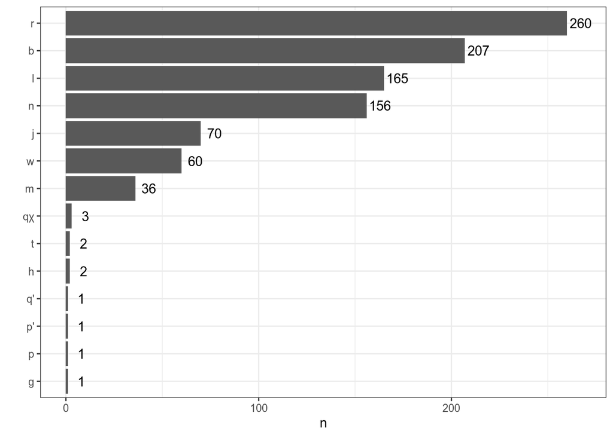

```r
godoberi_ipa_in_fi %>%
  filter(final_length == 1) %>%
  count(final, sort = TRUE) %>%
  ggplot(aes(n, fct_reorder(final, n)))+
  geom_col()+
  geom_text(aes(label = n), nudge_x = 7)+
  labs(y = "")
```

Как видно, чаще всего в финали встречаются сонорные и `b`, остальные звуки встречаются крайне редко. Давайте докажем это:

```r
godoberi_ipa_in_fi %>%
  mutate(finale_cs = case_when(
    str_detect(final, "[rlnjwm]") ~ "sonorant",
    str_detect(final, "b") ~ "b",
    str_detect(final, "#") ~ "open syllable",
    TRUE ~ "obstruent"
  )) %>%
  count(finale_cs, sort = TRUE)
```

```
## # A tibble: 4 x 2
##   finale_cs         n
##   <chr>         <int>
## 1 open syllable  3866
## 2 sonorant        752
## 3 b               207
## 4 obstruent        11
```

Какие звуки могут составлять инициаль?

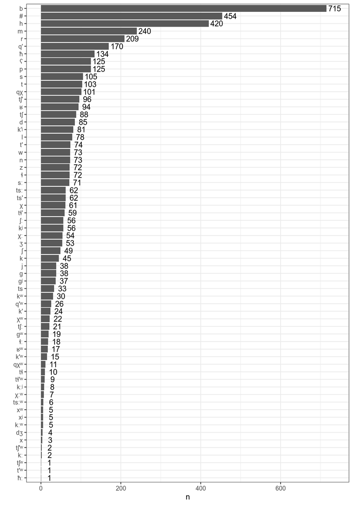

```r
godoberi_ipa_in_fi %>%
  filter(initial_length < 2) %>%
  count(initial, sort = TRUE) %>%
  ggplot(aes(n, fct_reorder(initial, n)))+
  geom_col()+
  geom_text(aes(label = n), nudge_x = 20)+
  labs(y = "")
```

Мы видим, что опять лидирует `b`, а в остальном, каких-то чеких преференций не видно. Вообще, появление `b` достаточно естественно: это показатель третьего класса, который составители словаря использовали как дефолтный во всех случаях, когда в лексемах был слот для классного согласования.

Теперь остался последний шаг: проверка кластеров согласных в середине слова. Если количество согласных в интервокальных кластерах не превышает 2, то тогда наша модель описывает все случаи, представлнные в нашем словаре.

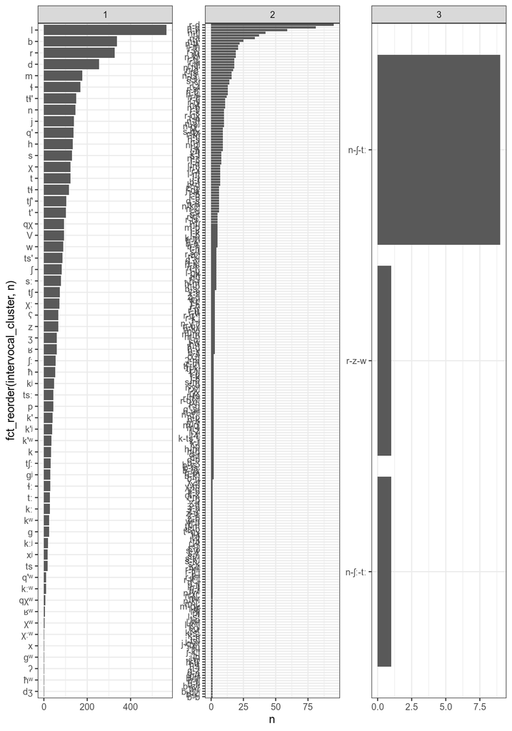

```r
godoberi_ipa %>%
  mutate(IPA = str_replace_all(IPA, vowels, "V"),
         intervocal_cluster = str_extract_all(IPA, "V.*?V")) %>%
  unnest(cols = "intervocal_cluster") %>%
  mutate(intervocal_cluster = str_remove_all(intervocal_cluster, "(V-)|(-V)"),
         intervocal_length = str_count(intervocal_cluster, "-")+1) %>%
  count(intervocal_cluster, intervocal_length) %>%
  ggplot(aes(n, fct_reorder(intervocal_cluster, n)))+
  geom_col()+
  facet_wrap(~intervocal_length, scales = "free")
```

Как видно, наша модель не предсказывает всего 11 слов с кластерами `n-ʃ-tː` (9), `n-ʃː-tː` (1) и `r-z-w` (1). Первые два кластера входят в слова со значением ‘5’, а последний кластер входит в слово, связанное с звукоподражением `zwarzwasí` ‘звенеть’. В связи с этим, можно считать, что наша модель описывает все слоговые структуры словаря. Этого не видно из рисунка, но большинство кластеров содержат сонорный в начале:

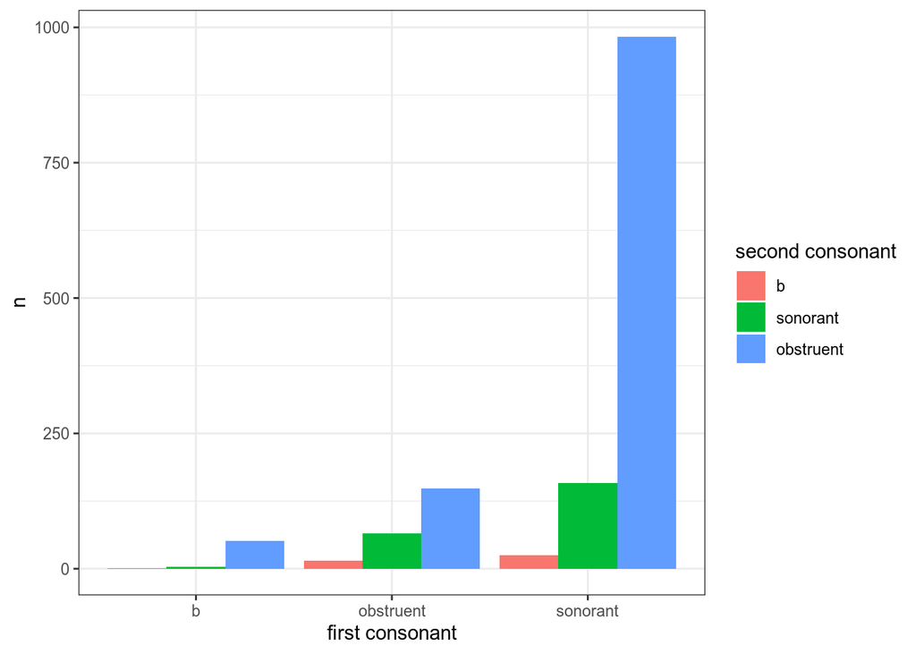

```r
godoberi_ipa %>%
  mutate(IPA = str_replace_all(IPA, vowels, "V"),
         intervocal_cluster = str_extract_all(IPA, "V.*?V")) %>%
  unnest(cols = "intervocal_cluster") %>%
  mutate(intervocal_cluster = str_remove_all(intervocal_cluster, "(V-)|(-V)"),
         intervocal_length = str_count(intervocal_cluster, "-")+1) %>%
  filter(intervocal_length == 2) %>%
  separate(intervocal_cluster, into = c("cons1", "cons2"), sep = "-") %>%
  mutate(cons1 = case_when(
    str_detect(cons1, "[rlnjwm]") ~ "sonorant",
    str_detect(cons1, "b") ~ "b",
    TRUE ~ "obstruent"
    ),
    cons2 = case_when(
    str_detect(cons2, "[rlnjwm]") ~ "sonorant",
    str_detect(cons2, "b") ~ "b",
    TRUE ~ "obstruent"
    )) %>%
count(cons1, cons2) %>%
  ggplot(aes(fct_reorder(cons1, n), fill = fct_reorder(cons2, n), n))+
  geom_col(position = "dodge")+
  labs(x = "first consonant",
       fill = "second consonant")
```

Как видно из графика, в большинстве случаев певрый согласный – сонорный, а второй согласный шумный, однако бывают и другие варианты. Это согласуется со сделанным ранее наблюдением, что сонорные тяготеют к финали слога.

## Результаты:

Слоговая структура годоберинского языка, вычисленная на основе 4837 слов, имеет вид (C)V(C).

- V `ũ` ‘да’
- CV `tʃ'i` ‘суповая тарелка’
- VC `up` ‘ничего (при отрицании)’
- CVC `beːl` ‘гора’

Существует несколько исключений, которые не вписываются в эту модель:

- числительное `inʃtːúda` и его однокоренные, а также еще пять слов
  - `harsː` гоп (выкрик танцующего мужчины)
  - `ʕebsːaqχurʃː` зоол. бокоплав
  - `parsː` крутая скала
  - `tsːudu*nparʃː` сорт абрикоса
  - `ʃːuru*nq'ʷerq'` черепаха;
- разные звукоподражания и оклики `tpru` ‘возглас, которым понукают лошадей’, `zwarzwasí` ‘звенеть’

Согласные по-разному распределены по разным частям слога: в финали есть сильная тенденция иметь сонорный или `b`, шумная финаль встречается в основном в звукоподражаниях или арабских, тюркских, персидских или русских заимствованиях, например, `awaráɡ` ‘пророк’, `ustóroʒ` ‘сторож’ и др.

## Ударение

Ударение в андийских языках таинственное, так что я бы не ожидал здесь великих открытий:

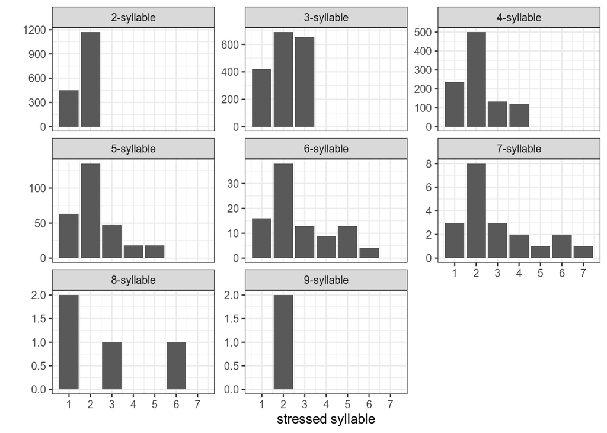

```r
godoberi_ipa %>%
  mutate(IPA = str_replace_all(IPA, "[auieo]̃?ː?", "V"),
         IPA = str_remove_all(IPA, "[^V*]"),
         n_syllables = str_count(IPA, "V"),
         stressed = str_length(str_extract(IPA, "V{1,}\\*?"))-1) %>%
  filter(n_syllables > 1) %>%
  count(n_syllables, stressed) %>%
  na.omit() %>%
  mutate(n_syllables = str_c(n_syllables, "-syllable")) %>%
  ggplot(aes(stressed, n))+
  geom_col(position = "dodge")+
  facet_wrap(~n_syllables, scales = "free_y")+
  labs(x = "stressed syllable", y = "")+
  scale_x_continuous(breaks = 1:7)
```

Как видно из графика существует большая тенденция иметь ударение на втором слоге, однако в трехсложных словах эта тенденция не сильно превосходит ударение на третьем слоге. Данное исследование следует продолжить, разметив части речи. Беглый анализ показал, что ударность слога не связаны со структурой слога или качеством гласного.